# MSCA 31006 Time Series - Final Project - EDA

Whitney Schreiber, Anna Auersperg

2022-05-08

```r
# load packages
suppressPackageStartupMessages({
  library(dplyr)
  library(ggplot2)
  library(zoo)
  library(xts)
  library(tseries)
  library(forecast)
  library(TSA)
  library(reshape2)
  library(naniar)
  library(lubridate)
})
```

# Daily Average Temperature of Major Cities

Daily temperature of major cities data downloaded from: https://www.kaggle.com/datasets/sudalairajkumar/daily-temperature-of-major-cities?resource=download

Data set includes the daily average temperature between 1995-2020 for 321 different cities in 125 different countries in 7 different regions

Variables:

- `Region`
- `Country`
- `State` (note: corresponds to US/US territories, blank otherwise)
- `City`
- `Month`
- `Day`
- `Year`
- `AvgTemperature`

```r
# import data
raw_df <- read.csv("city_temperature.csv")
str(raw_df)
```

```
## 'data.frame':    2906327 obs. of  8 variables:
##  $ Region        : chr  "Africa" "Africa" "Africa" "Africa" ...
##  $ Country       : chr  "Algeria" "Algeria" "Algeria" "Algeria" ...
##  $ State         : chr  "" "" "" "" ...
##  $ City          : chr  "Algiers" "Algiers" "Algiers" "Algiers" ...
##  $ Month         : int  1 1 1 1 1 1 1 1 1 1 ...
##  $ Day           : int  1 2 3 4 5 6 7 8 9 10 ...
##  $ Year          : int  1995 1995 1995 1995 1995 1995 1995 1995 1995 1995 ...
##  $ AvgTemperature: num  64.2 49.4 48.8 46.4 47.9 48.7 48.9 49.1 49 51.9 ...
```

```r
head(raw_df)
```

```
##   Region Country State    City Month Day Year AvgTemperature
## 1 Africa Algeria       Algiers     1   1 1995           64.2
## 2 Africa Algeria       Algiers     1   2 1995           49.4
## 3 Africa Algeria       Algiers     1   3 1995           48.8
## 4 Africa Algeria       Algiers     1   4 1995           46.4
## 5 Africa Algeria       Algiers     1   5 1995           47.9
## 6 Africa Algeria       Algiers     1   6 1995           48.7
```

# Cities around the world

```r
# unique values
lapply(raw_df %>% dplyr::select(-c("AvgTemperature")),unique)
```

```
## $Region
## [1] "Africa"                            "Asia"
## [3] "Australia/South Pacific"           "Europe"
## [5] "Middle East"                       "North America"
## [7] "South/Central America & Carribean"
##
## $Country
##   [1] "Algeria"                  "Burundi"
##   [3] "Benin"                    "Central African Republic"
##   [5] "Congo"                    "Egypt"
##   [7] "Ethiopia"                 "Gabon"
##   [9] "Gambia"                   "Guinea"
##  [11] "Guinea-Bissau"            "Ivory Coast"
##  [13] "Kenya"                    "Morocco"
##  [15] "Madagascar"               "Mauritania"
```

[output cut: 195 more lines]

```r
# length of unique values
lapply(
  lapply(raw_df %>% dplyr::select(-c("AvgTemperature")),unique),
  length)
```

```
## $Region
## [1] 7
##
## $Country
## [1] 125
##
## $State
## [1] 53
##
## $City
## [1] 321
##
## $Month
## [1] 12
##
## $Day
## [1] 32
##
## $Year
## [1] 28
```

Explore unusual `Day` and `Year` values

- `Day` 0
- `Year` 200
- `Year` 201

```r
# raw_df[which(raw_df$Day==0 | raw_df$Year==200 | raw_df$Year==201),]
raw_df[which(raw_df$Day==0 | raw_df$Year==200 | raw_df$Year==201),"Country"] %>%
  unique()
```

```
##  [1] "Ethiopia"      "Guinea"        "Guinea-Bissau" "Kenya"
##  [5] "Malawi"        "Mozambique"    "Nigeria"       "Tanzania"
##  [9] "Uganda"        "Germany"       "Norway"        "Mexico"
## [13] "Cuba"
```

```r
# remove observations with year = 200, 201 or 2020 (only partial data), Day = 0
raw_df <- raw_df %>%
  filter(!Year %in% (200:201)) %>%
  #filter(Year < 2020) %>%
  filter(Day != 0)
```

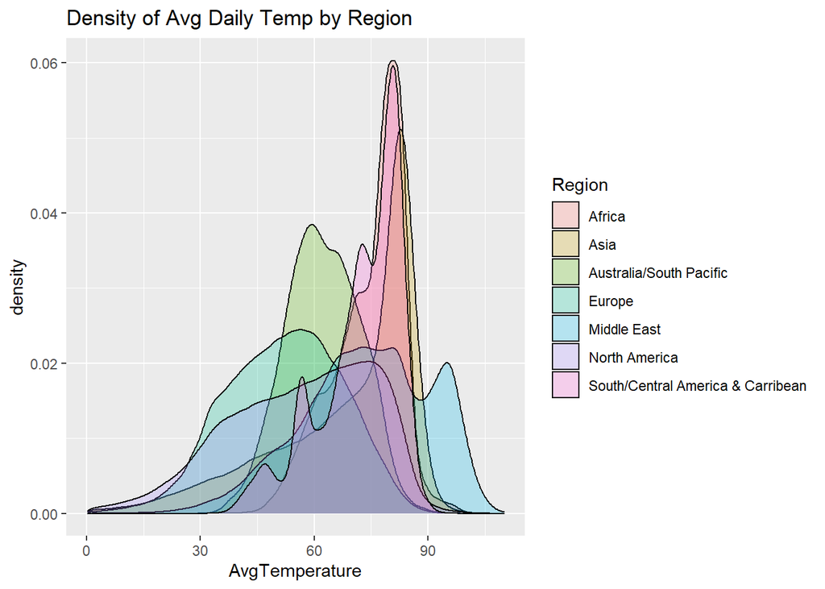

```r
# density plot
raw_df %>%
  filter(AvgTemperature>0) %>%
  ggplot(aes(AvgTemperature)) +
  geom_density(aes(fill=Region), alpha=1/4) +
  ggtitle("Density of Avg Daily Temp by Region")
```

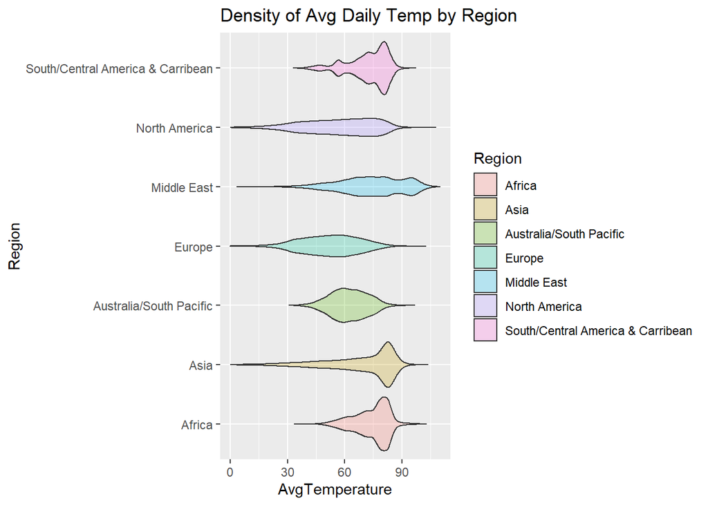

```r
# violin plot
raw_df %>%
  filter(AvgTemperature>0) %>%
  ggplot(aes(Region,AvgTemperature)) +
  geom_violin(aes(fill=Region), alpha=1/4) +
  coord_flip() +
  ggtitle("Density of Avg Daily Temp by Region")
```

### Avg Temperature per Year

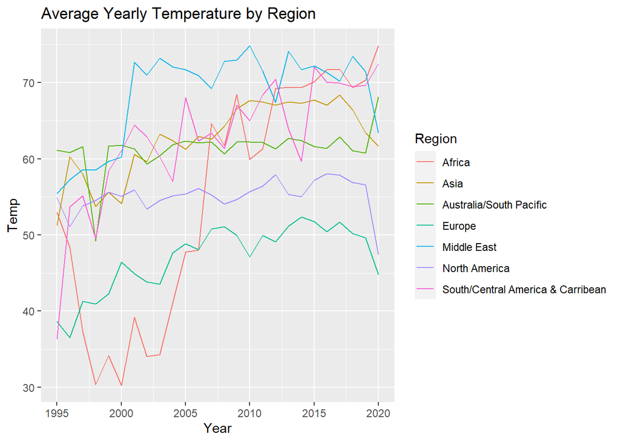

```r
raw_df %>% filter(., !is.na(AvgTemperature)) %>%
  group_by(Region,Year,.groups='keep') %>%
  summarise(Temp = mean(AvgTemperature)) %>%
  ggplot(aes(x = Year, y = Temp,color=Region)) +
  geom_line() +
  ggtitle("Average Yearly Temperature by Region")
```

### Cities with Highest Avg Temp

```r
hot_cities <- raw_df %>%
  filter(., !is.na(AvgTemperature)) %>%
  group_by(City) %>%
  summarise(avg_temp = mean(AvgTemperature, na.rm = TRUE)) %>%
  ungroup() %>%
  top_n(n = 10, wt = avg_temp) %>% arrange(-avg_temp)
hot_cities
```

```
## # A tibble: 10 x 2
##    City             avg_temp
##    <chr>               <dbl>
##  1 Dubai                83.0
##  2 Chennai (Madras)     82.8
##  3 Doha                 82.2
##  4 Abu Dhabi            82.2
##  5 Niamey               82.0
##  6 Singapore            81.7
##  7 Manila               81.5
##  8 Bombay (Mumbai)      81.5
##  9 Manama               80.6
## 10 Vientiane            80.0
```

# Cities in the US

```r
# filter for 'US', excluding 'US territories'
df.usa <- raw_df %>% dplyr::filter((Country=="US") &
                                   (State!="Additional Territories"))
# drop redundant columns
df.usa <- df.usa %>% select(-c("Region", "Country"))
# check for null values
df.usa[is.na(df.usa)]
```

```
## character(0)
```

Create `Date` field

```r
df.usa <- df.usa %>%
  mutate(Date = as.Date(with(df.usa,paste(Year,Month,Day,sep="-")),
                        "%Y-%m-%d")) %>%
  select(-c("Month","Day","Year"))
head(df.usa)
```

```
##     State       City AvgTemperature       Date
## 1 Alabama Birmingham           50.7 1995-01-01
## 2 Alabama Birmingham           37.2 1995-01-02
## 3 Alabama Birmingham           33.2 1995-01-03
## 4 Alabama Birmingham           33.3 1995-01-04
## 5 Alabama Birmingham           26.4 1995-01-05
## 6 Alabama Birmingham           41.5 1995-01-06
```

```r
# number of days between the start and end date (inclusive)
n_days <- max(df.usa$Date)-min(df.usa$Date)+1
# confirm all (unique) dates are included
df.usa$Date %>% unique() %>% length() == n_days
```

```
## [1] TRUE
```

```r
# print date range and n_days
cbind("start date"=min(df.usa$Date),
      "end date"=max(df.usa$Date),
      "number of days"=n_days)
```

```
##      start date end date number of days
## [1,]       9131    18395           9265
```

### Check dates and cities

1. all dates included for all cities
2. no repeated dates in cities

```r
# number of records per day in the US
dateCountUS <- df.usa %>% dplyr::count(Date)
# unique values
dateCountUS$n %>% unique() %>% sort()
```

```
## [1] 152 153 154 157 158 159
```

Each date does not include a record for every city in the US. Determine which cities are missing days.

```r
# number of records in each city
cityCountUS <- df.usa %>% dplyr::count(City)
# cities with incomplete date range dates
(incompleteCityUS <- cityCountUS %>% dplyr::filter(cityCountUS$n != n_days))
```

```
##             City     n
## 1        Abilene  9266
## 2    Baton Rouge  5798
## 3     Charleston 18530
## 4       Columbus 18530
## 5  Daytona Beach  5751
## 6      Flagstaff  3574
## 7     Harrisburg  5751
## 8         Helena  9264
## 9       Portland 18530
## 10   Springfield 18530
## 11    Washington 18530
## 12 Washington DC 18530
## 13    Wilmington  5751
## 14          Yuma  4380
```

Washington DC, Maryland and Washington, District of Columbia appear to have twice the number of records as days. Remove exact duplicates. Check whether the data for “Washington DC, Maryland” and “Washington, District of Columbia” are the same.

```r
# Remove duplicate values
df.usa <- df.usa %>% distinct()
```

```r
all(df.usa[which(df.usa$City=="Washington DC, Maryland"),"AvgTemperature"] ==
    df.usa[which(df.usa$City=="Washington, District of Columbia"),"AvgTemperature"])
```

```
## [1] TRUE
```

Remove records for Washington DC, Maryland

```r
df.usa <- df.usa %>% dplyr::filter(City!="Washington DC, Maryland")
df.usa %>%
  dplyr::filter(City=="Washington, District of Columbia") %>%
  dplyr::count(City)
```

```
## [1] City n
## <0 rows> (or 0-length row.names)
```

Check the *new* number of records in each city.

```r
cityCountUS <- df.usa %>% dplyr::count(City)
(incompleteCityUS <- cityCountUS %>% dplyr::filter(cityCountUS$n != n_days))
```

```
##             City     n
## 1        Abilene  9266
## 2    Baton Rouge  5798
## 3     Charleston 18530
## 4       Columbus 18530
## 5  Daytona Beach  5751
## 6      Flagstaff  3574
## 7     Harrisburg  5751
## 8         Helena  9264
## 9       Portland 18530
## 10   Springfield 18530
## 11    Wilmington  5751
## 12          Yuma  4380
```

- Most of these cities are missing a substantial number of days (nearly 50%).
- Abilene, Texas has an additional record that is not an exact duplicate

```r
# remove cities with incomplete data
df.usa <- df.usa %>% dplyr::filter(!(City %in% incompleteCityUS$City))
```

Confirm that the number of records per day matches the number of cities

```r
# re-check number of records per day in the US
dateCountUS <- df.usa %>% dplyr::count(Date)
dateCountUS$n %>% unique() == df.usa$City %>% unique() %>% length()
```

```
## [1] TRUE
```

```r
# confirm that the number of days in the data set has not changed
df.usa$Date %>% unique() %>% length() == n_days
```

```
## [1] TRUE
```

## Summary statistics of `AvgTemperature` in US

```r
summary(df.usa$AvgTemperature)
```

```
##    Min. 1st Qu.  Median    Mean 3rd Qu.    Max.
##   -99.0    42.6    58.5    56.0    72.0   107.7
```

The minimum average temperature is -99, this is a placeholder for missing data.

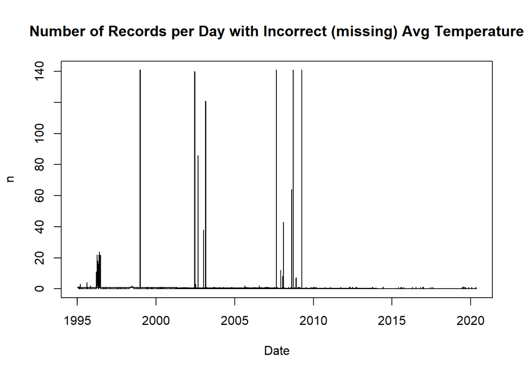

```r
# number of records with AvgTemperature "-99" by date
dailycount99 <- df.usa[which(df.usa$AvgTemperature==-99),] %>%
  dplyr::count(Date)
# left join the complete dates and the "-99" counts
dfdailycount99 <- df.usa %>% select(Date) %>%
  left_join(dailycount99, by="Date")
# replace na with 0
dfdailycount99[is.na(dfdailycount99)] <- 0
# plot the number of "-99" records with a "-99" AvgTemperature each day
plot(dfdailycount99, type="l",
     main="Number of Records per Day with Incorrect (missing) Avg Temperature")
```

Number of records missing (“-99”) `AvgTemperature` in each city

```r
cityCount99 <- df.usa[which(df.usa$AvgTemperature==-99),] %>%
  dplyr::count(City)
# calculate pct missing
cityCount99$nPct <- cityCount99$n / as.numeric(n_days)
summary(cityCount99)
```

```
##      City                 n               nPct
##  Length:141         Min.   : 12.00   Min.   :0.001295
##  Class :character   1st Qu.: 16.00   1st Qu.:0.001727
##  Mode  :character   Median : 19.00   Median :0.002051
##                     Mean   : 23.67   Mean   :0.002555
##                     3rd Qu.: 25.00   3rd Qu.:0.002698
##                     Max.   :146.00   Max.   :0.015758
```

Overall, the number of records with missing (“-99”) `AvgTemperature` in each city is small.

#### Update values where `AvgTemperature` = -99 by forward filling

```r
df.usa %>% dplyr::filter((Date==as.Date("1995-02-07")) & (AvgTemperature==-99))
```

```
## [1] State          City           AvgTemperature Date
## <0 rows> (or 0-length row.names)
```

```r
df.usa <- df.usa %>% mutate(AvgTemperature = na_if(AvgTemperature, -99)) %>%
  mutate(., AvgTemperature = na.locf(AvgTemperature, fromLast = FALSE))
```

# Data exploration of average temperature across the US

```r
meanUS <- df.usa %>%
  group_by(Year_Month = as.yearmon(Date)) %>%
  summarise(AvgTemp = round(mean(AvgTemperature), 2))
```

## Change in extreme temps

clear seasonality

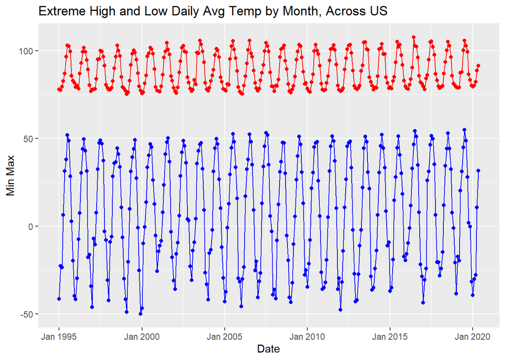

```r
extreme <- df.usa %>% group_by(Year_Month = as.yearmon(Date)) %>%
  summarise(AvgTemp = round(mean(AvgTemperature), 2),
            Max = max(AvgTemperature),
            Min = min(AvgTemperature))
# plot
ggplot(extreme) +
  geom_line(aes(x = Year_Month, y = Min), col = "Blue") +
  geom_point(aes(x = Year_Month, y = Min), col = "Blue") +
  geom_line(aes(x = Year_Month, y = Max), col = "Red") +
  geom_point(aes(x = Year_Month, y = Max), col = "Red") +
  labs(x ="Date", y = "Min Max") +
  ggtitle("Extreme High and Low Daily Avg Temp by Month, Across US")
```

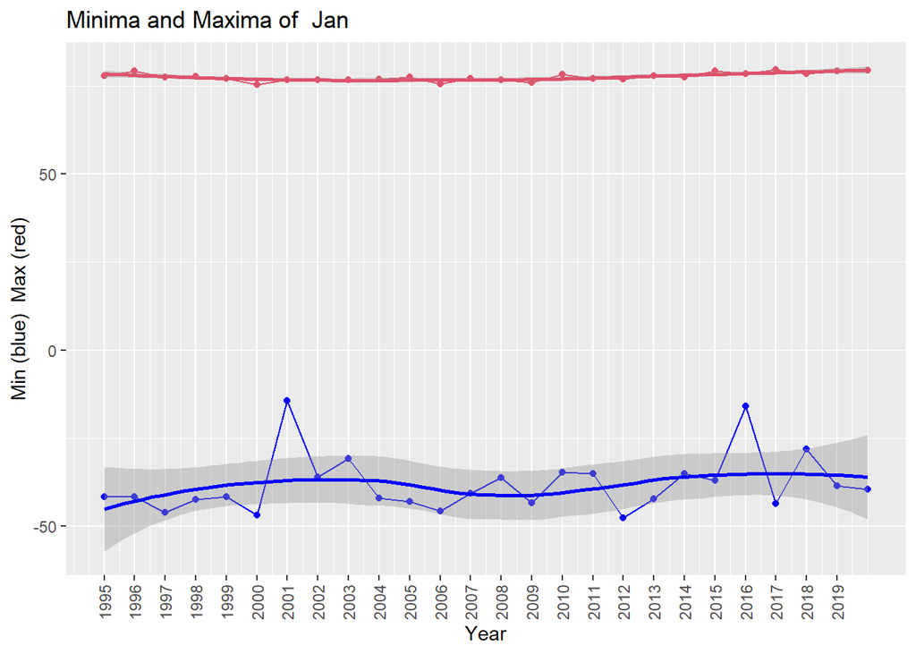

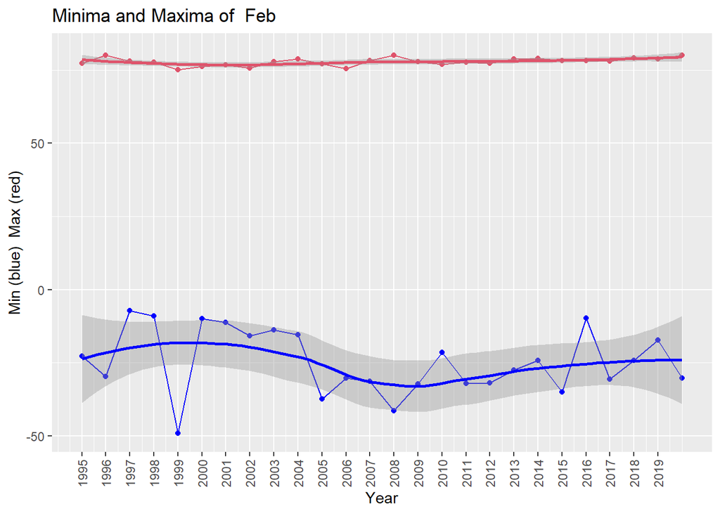

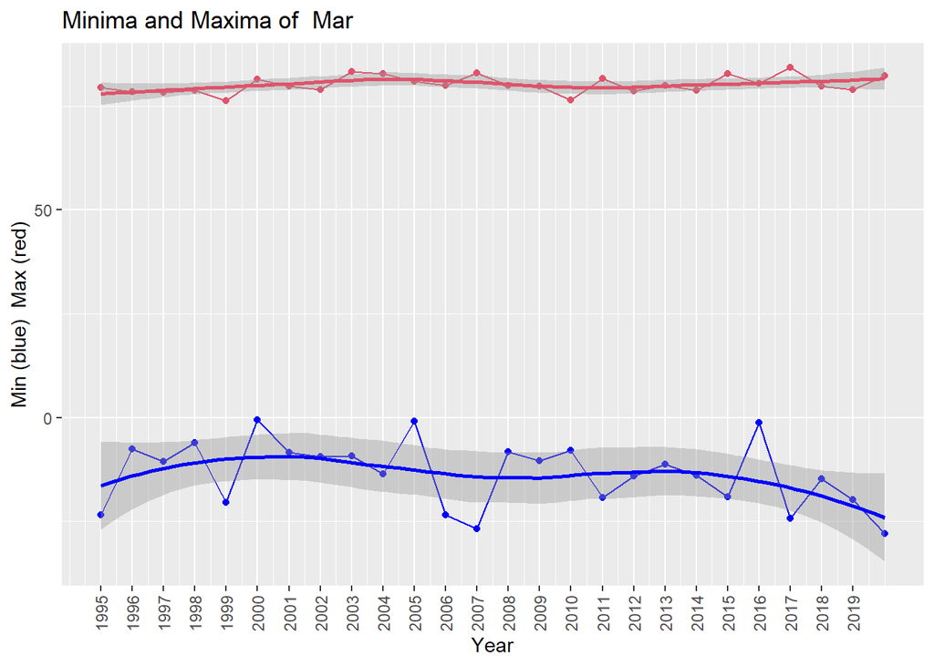

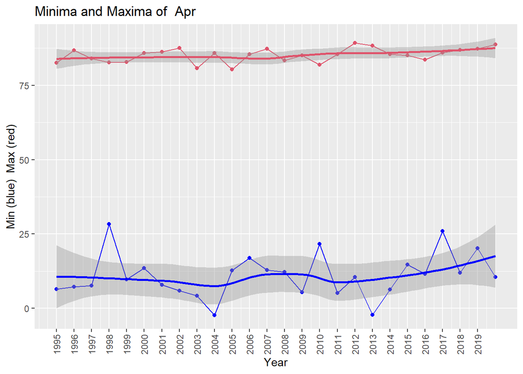

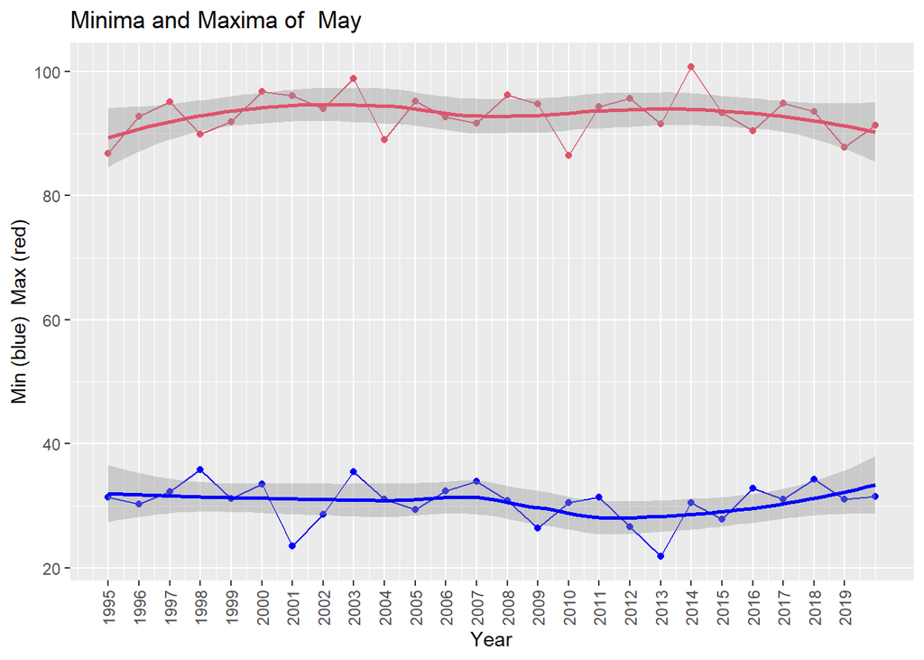

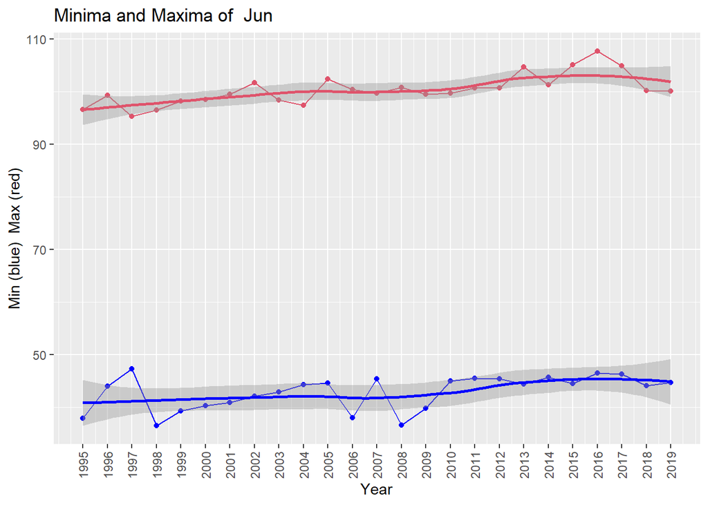

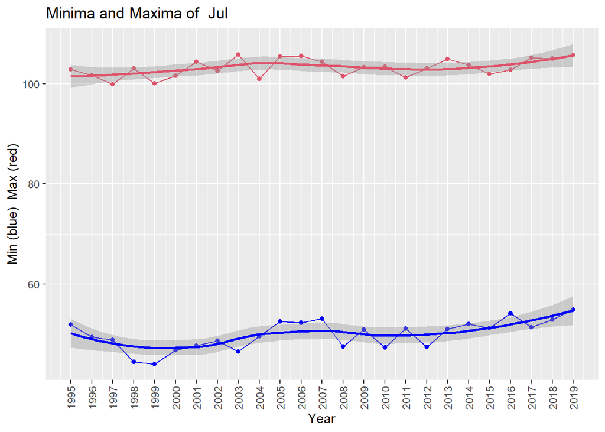

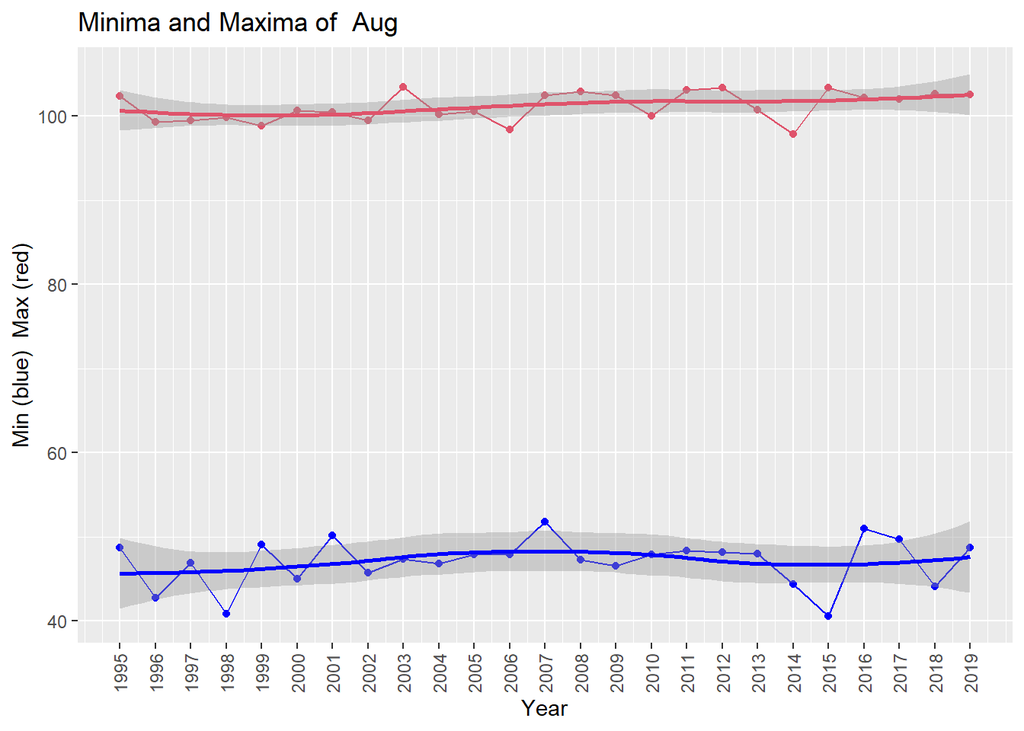

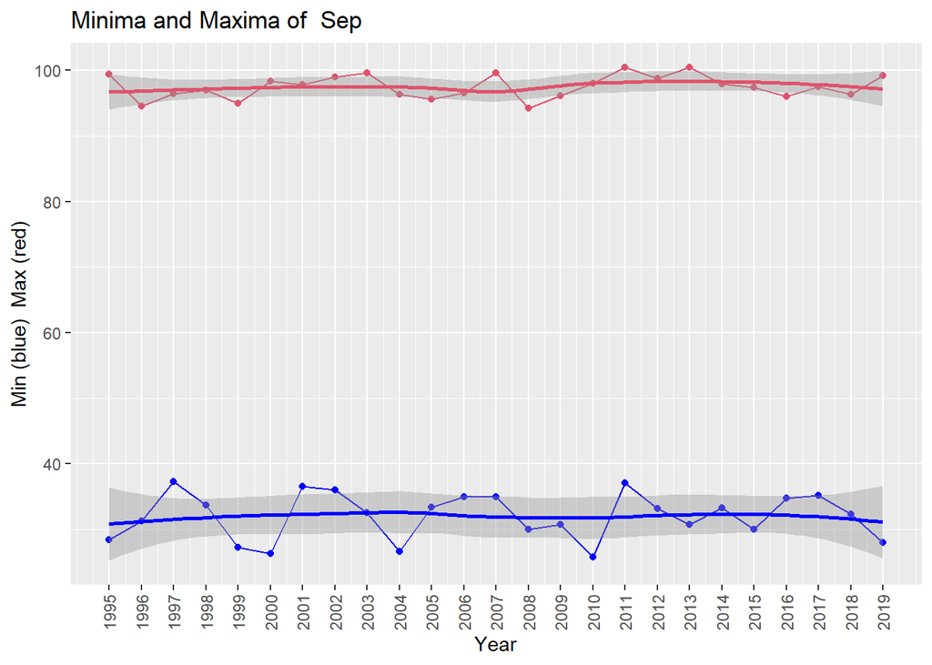

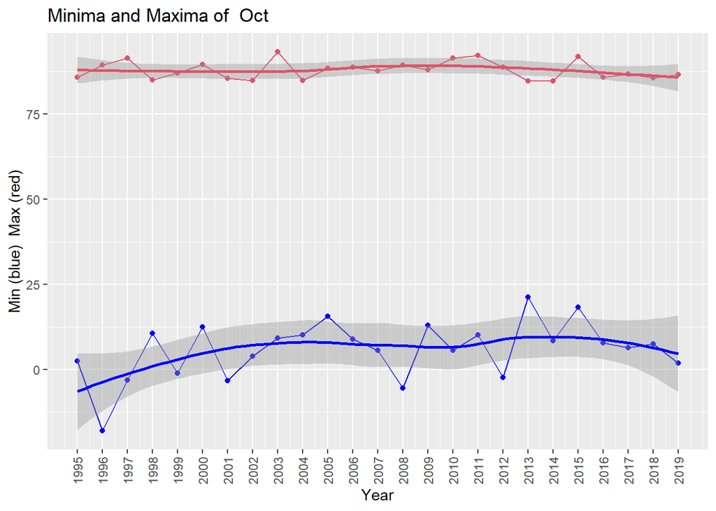

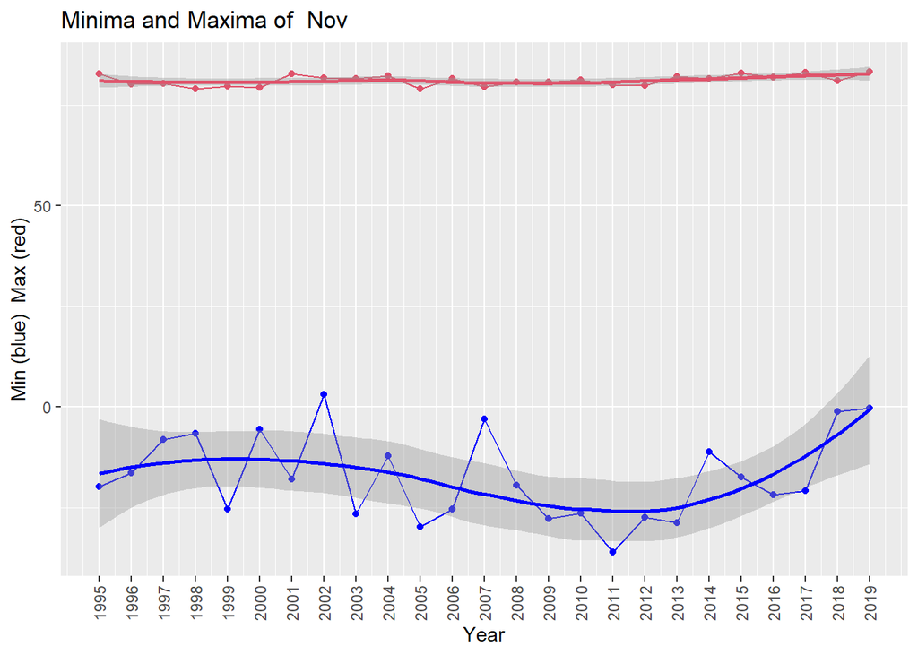

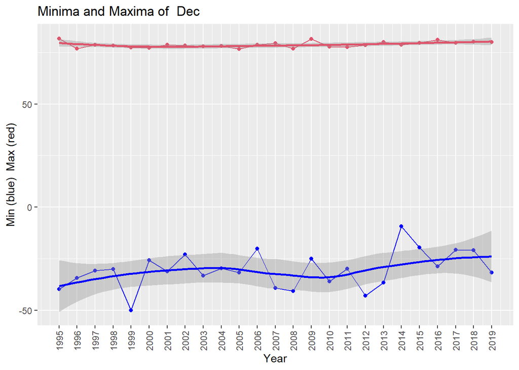

```r
extreme.mnthly <- function(m){
  minimax <- extreme %>% filter(month(Year_Month) == m)
  ggplot(data = minimax) +
    geom_line(aes(x = year(Year_Month), y = Min), col = "Blue") +
    geom_point(aes(x = year(Year_Month), y = Min), col = "Blue") +
    geom_smooth(aes(x = year(Year_Month), y = Min), col = "Blue") +
    geom_line(aes(x = year(Year_Month), y = Max), col = 2) +
    geom_point(aes(x = year(Year_Month), y = Max), col = 2) +
    geom_smooth(aes(x = year(Year_Month), y = Max), col = 2) +
    scale_x_continuous(breaks = seq(1995, 2019, by = 1)) +
    labs(title = paste("Minima and Maxima of ",month.abb[m]), x = "Year", y = "Min (blue)  Max (red)")  +
    theme(axis.text.x = element_text(angle = 90, vjust = 0.5))
}
lapply(unique(month(meanUS$Year_Month)),extreme.mnthly)
```

## Average temperature across the continental US

### Daily

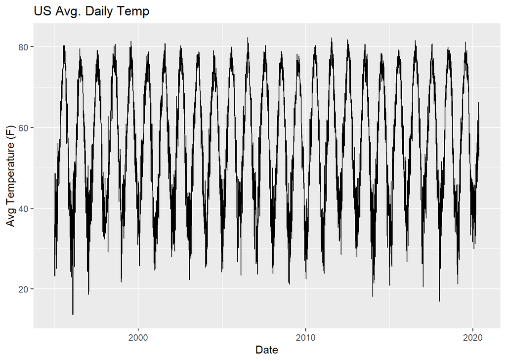

```r
#chi <- df.usa %>% filter(City == 'Chicago, Illinois')
df.usa %>% group_by(Date) %>%
  summarise(Avg = mean(AvgTemperature)) %>%
  ggplot(aes(Date, Avg)) +
  geom_line() +
  labs(title = 'US Avg. Daily Temp', y = "Avg Temperature (F)", x = "Date")
```

```r
adf.test(df.usa$AvgTemperature)
```

```
##
##  Augmented Dickey-Fuller Test
##
## data:  df.usa$AvgTemperature
## Dickey-Fuller = -128.44, Lag order = 109, p-value = 0.01
## alternative hypothesis: stationary
```

```r
kpss.test(df.usa$AvgTemperature)
```

```
##
##  KPSS Test for Level Stationarity
##
## data:  df.usa$AvgTemperature
## KPSS Level = 24.517, Truncation lag parameter = 42, p-value = 0.01
```

### Monthly

Define function to plot the variation in average temperature of a month (year over year)

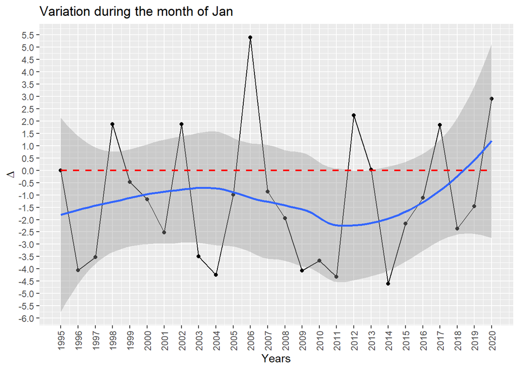

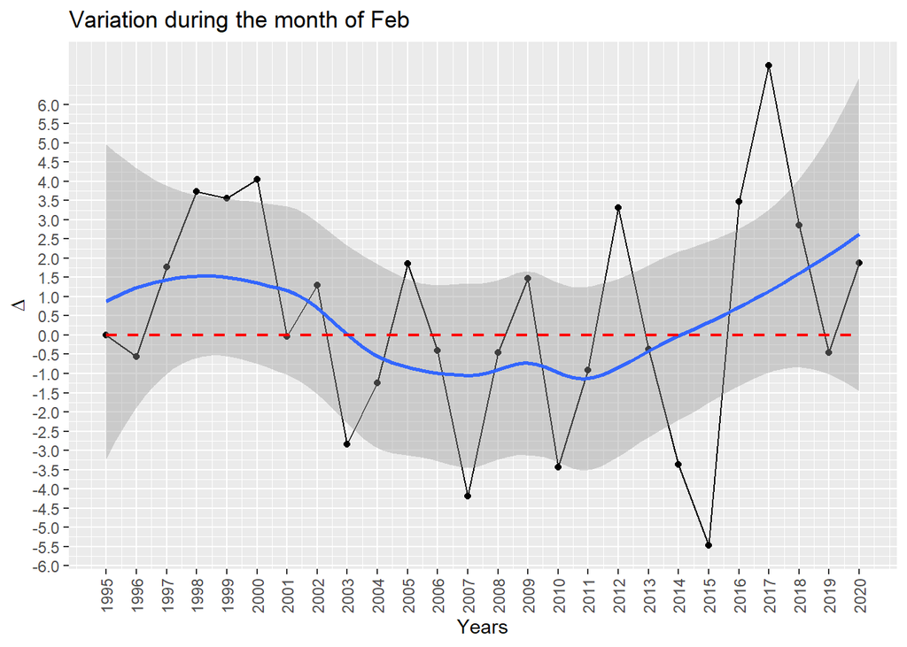

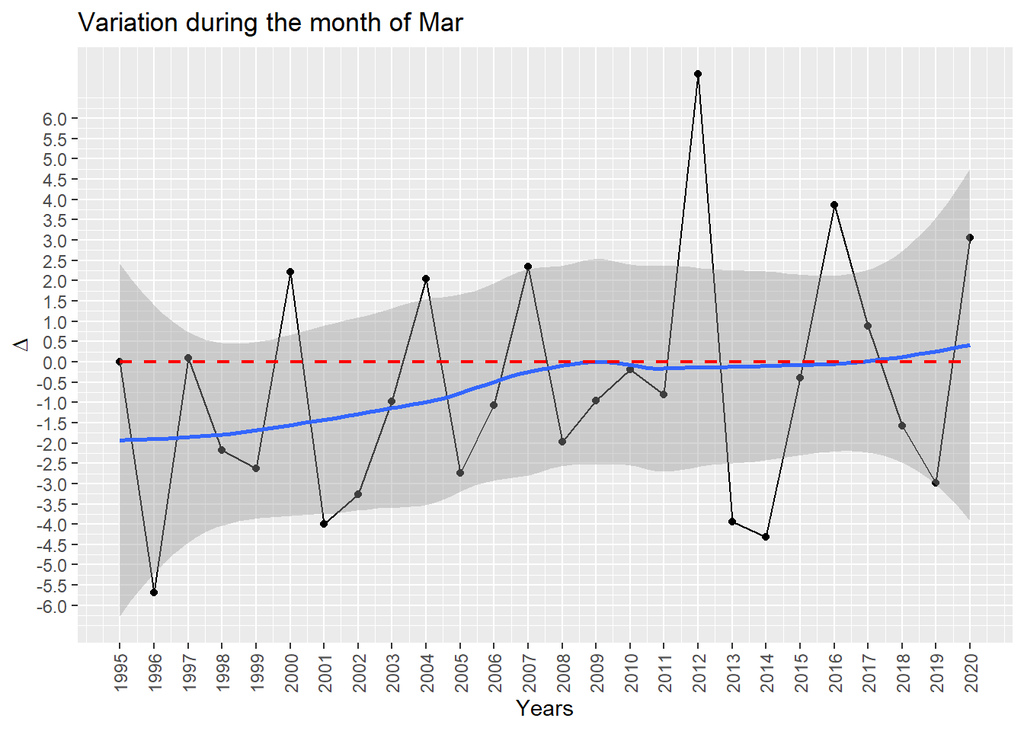

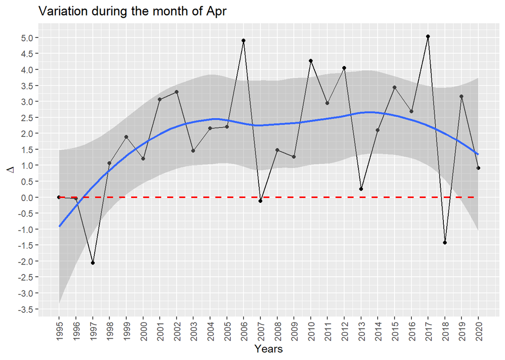

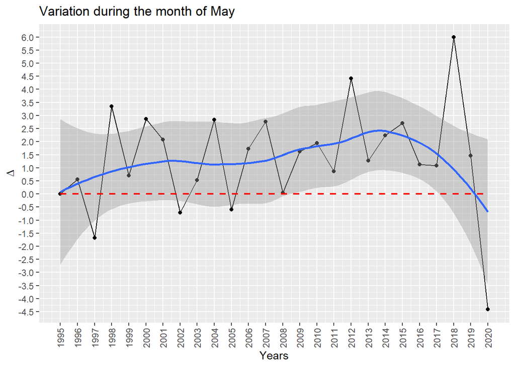

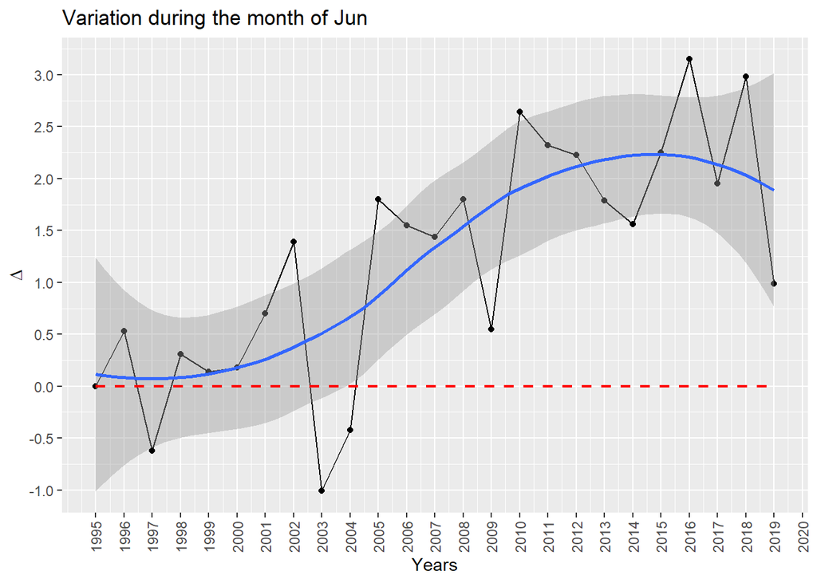

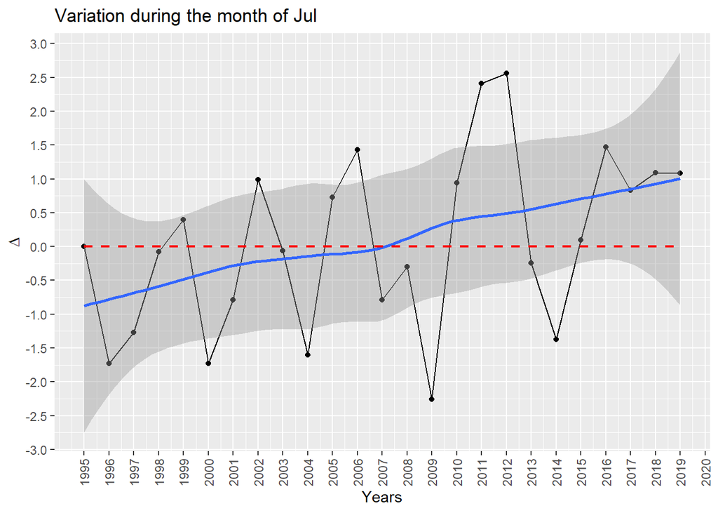

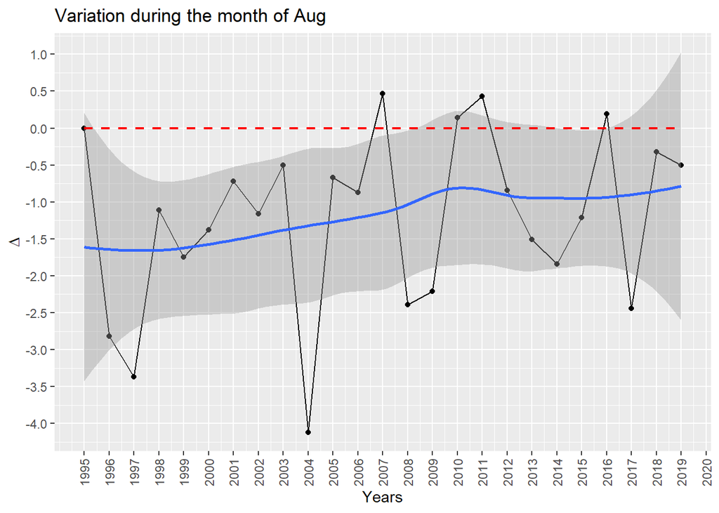

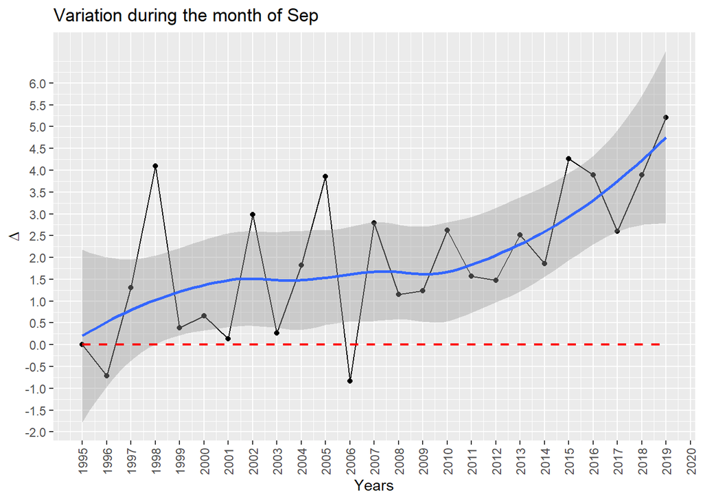

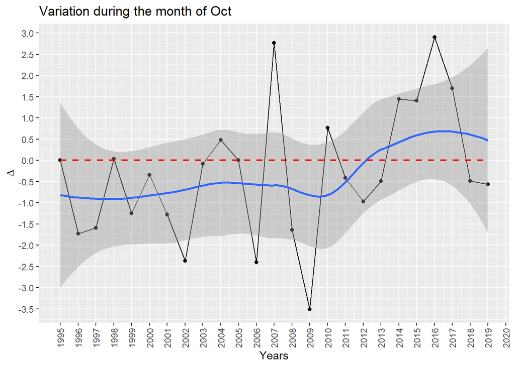

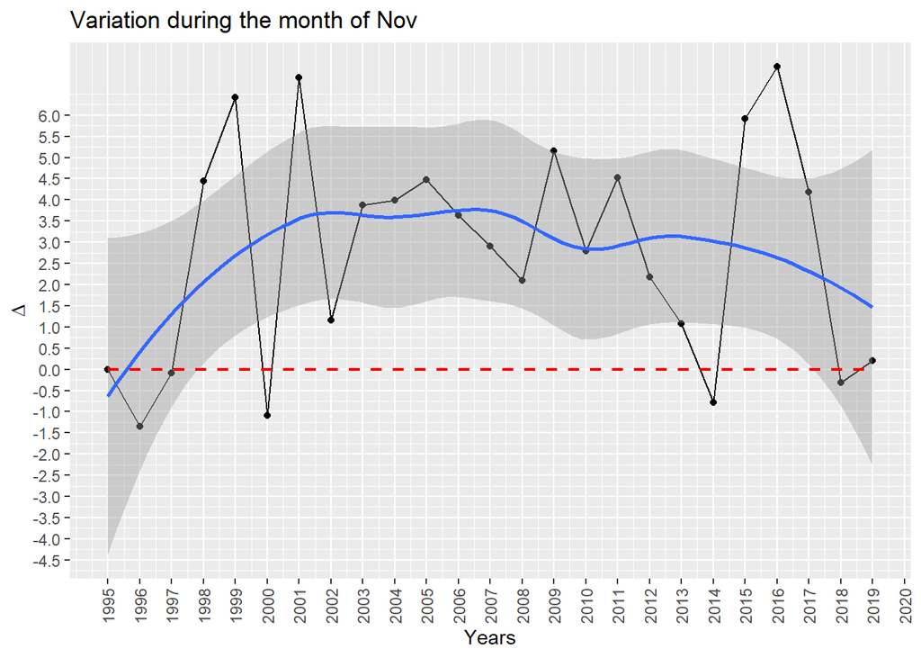

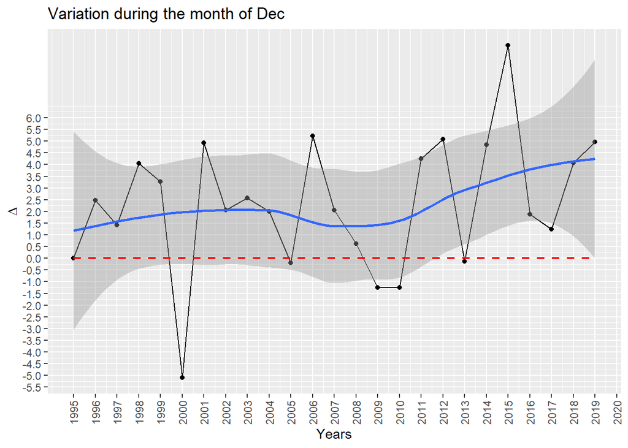

```r
month.delta <- function(m){
  # subset by month
  mnthly.mean <- meanUS %>% filter(month(Year_Month) == m)
  # calculate the change in average temp from the FIRST month
  delta <- round(mnthly.mean$AvgTemp - mnthly.mean$AvgTemp[1],2)
  # plot
  ggplot(data = mnthly.mean) +
    geom_point(aes(x = year(Year_Month), y = delta))  +
    geom_line(aes(x = year(Year_Month), y = delta)) +
    geom_smooth(aes(x = year(Year_Month), y = delta)) +
    scale_x_continuous(breaks = seq(1995, 2020, by = 1)) +
    scale_y_continuous(breaks = seq(-6, 6, by = 0.5)) +
    geom_line(aes(x = year(Year_Month), y = delta[1]), colour = "red", linetype = "dashed", size = 0.8) +
    theme(axis.text.x = element_text(angle = 90, vjust = 0.5)) +
    labs(title = paste("Variation during the month of", month.abb[m]),
      y = expression(paste(Delta)),
      x = "Years")
}
lapply(unique(month(meanUS$Year_Month)),month.delta)
```

### Yearly (1995 - 2019)

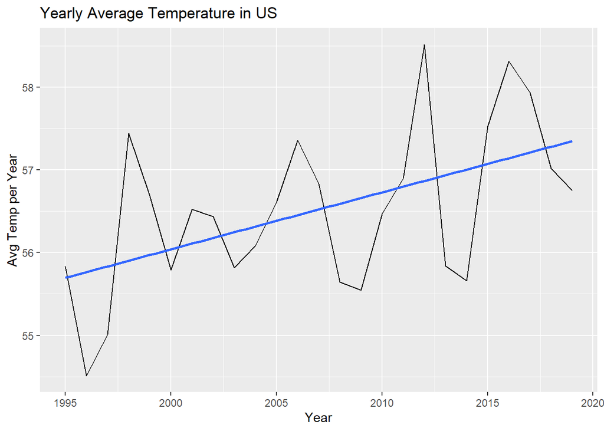

```r
df.usa %>% dplyr::filter(Date < as.Date("2020-01-01")) %>%
  group_by(Year = lubridate::year(Date)) %>%
  summarise(
    avg_year = mean(AvgTemperature)
  ) %>%
  ggplot(aes(Year, avg_year)) +
  geom_line() +
  geom_smooth(method = 'lm', se = F) +
  labs(y="Avg Temp per Year") +
  ggtitle("Yearly Average Temperature in US")
```

## Identify regions by use state datasets from R

```r
suppressPackageStartupMessages(library(datasets))
regions <- data.frame(State = state.name, Region = state.region)
df.usa <- left_join(df.usa, regions, by = "State")
```

```r
sapply(split(df.usa$AvgTemperature, df.usa$Region), summary)
```

```
##         Northeast     South North Central     West
## Min.    -20.90000  -4.20000     -29.80000 -50.0000
## 1st Qu.  36.70000  52.30000      34.40000  42.1000
## Median   51.80000  66.90000      51.30000  55.5000
## Mean     50.89913  63.98597      50.00665  54.3175
## 3rd Qu.  66.70000  77.30000      67.60000  67.8000
## Max.     95.60000 100.70000      96.30000 107.7000
```

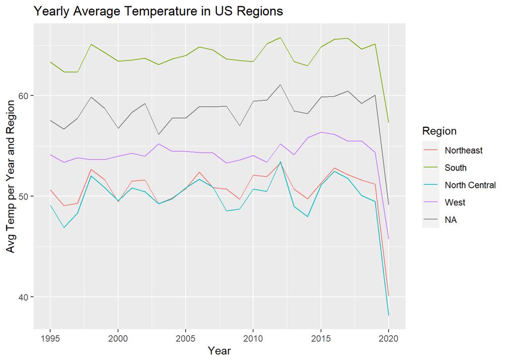

```r
df.usa %>%
  group_by(Year=lubridate::year(Date), Region) %>%
  summarise(
    avg_year = mean(AvgTemperature),
    .groups = 'keep'  # need to use when grouping by more than 1 variable
    ) %>% #ungroup() %>%
  ggplot() +
  geom_line(aes(Year, avg_year, color = Region)) +
  # facet_wrap(vars(Region)) +
  labs(y="Avg Temp per Year and Region") +
  ggtitle("Yearly Average Temperature in US Regions")
```

```r
options(repr.plot.width = 20, repr.plot.height = 20)
```